# Data analysis project - carry out an IPTW causal analysis - Week 4 Graded Quiz

Abstract

For this assignment we will use data from Lalonde (1986), that aimed to evaluate the impact of National Supported Work (NSW) Demonstration, which is a labor training program, on post-intervention income levels. Interest is in estimating the causal effect of this training program on income.

```r
# load pacakges
library(tableone)
library(Matching)
library(ipw) #compute inverse probability of treatment weights
library(survey) #to et weighted estimators
library(ggplot2)

# now load the lalonde data (which is in the MatchIt package)
data(lalonde, package = 'MatchIt')

# fix missing variables issue by creating black and hispan variables separately (using the levels form the race varible of lalonde)
lalonde$black <- as.integer(ifelse(lalonde$race == "black", 1, 0))
lalonde$hispan <- as.integer(ifelse(lalonde$race == "hispan", 1, 0))
# now drop race variable
lalonde <- subset(lalonde, select = -c(race))

View(lalonde)
```

## Dataset information

The data have n=614 subjects and 10 variables.

**age**: age in years.

**educ**: years of schooling.

**black**: indicator variable for blacks.

**hispan**: indicator variable for Hispanics.

**married**: indicator variable for marital status.

**nodegree**: indicator variable for high school diploma.

**re74**: real earnings in 1974.

**re75**: real earnings in 1975.

**re78**: real earnings in 1978.

**treat**: an indicator variable for treatment status.

The **outcome** is re78 – post-intervention income.

The **treatment** is treat – which is equal to 1 if the subject received the labor training and equal to 0 otherwise.

The **potential confounding** variables are: age, educ, black, hispan, married, nodegree, re74, re75.

### Q1 Tasks:

#### Fit a propensity score model. Use a logistic regression model, where the outcome is treatment. Include the 8 confounding variables in the model as predictors, with no interaction terms or non-linear terms (such as squared terms). Obtain the propensity score for each subject. Next, obtain the inverse probability of treatment weights for each subject.

```r
# 1. fit model
ps_model <- glm(formula = treat~age+educ+black+hispan+married+nodegree+re74+re75,
                data = lalonde,
                family = binomial())
# 2. obtain propensity scores
ps <- ps_model$fitted.values
# 3. weights (inverse probability of true treatment. if true treatment==1: 1/ps, else 1/(1-ps))
wt <- ifelse(test = lalonde$treat==1, yes = 1/ps, no = 1/(1-ps))
# 4. display summary of weights
summary(wt, digits=3)
```

```
   Min. 1st Qu.  Median    Mean 3rd Qu.    Max.
   1.01    1.05    1.17    1.90    1.62   40.10
```

### Q2 Tasks:

#### Find the standardized differences for each confounder on the weighted (pseudo) population. What is the standardized difference for nodegree?

```r
# 1. apply weighs to data
lalonde_weighted <- svydesign(ids = ~ 1, data = lalonde, weights = ~ wt) # survey design function
# 2. creat weighted table 1
xvars = colnames(lalonde_weighted)
# filter out treatment and outcome vars
xvars = xvars[colnames(lalonde_weighted) %in% c("treat", "re78") == FALSE]
table1_weighted <- svyCreateTableOne(vars = xvars , strata = "treat", data = lalonde_weighted, test = FALSE) # test = FALSE, to not perform significance testing

# 3. show table with standardized mean differences (SMD)
print(table1_weighted, smd = TRUE) # standardized mean difference (smd)
```

```
                      Stratified by treat
                       0                 1                 SMD
  n                     616.00            553.63
  age (mean (SD))        27.10 (10.80)     25.57 (6.53)     0.172
  educ (mean (SD))       10.29 (2.74)      10.61 (2.05)     0.132
  married (mean (SD))     0.41 (0.49)       0.31 (0.47)     0.197
  nodegree (mean (SD))    0.62 (0.48)       0.57 (0.50)     0.112
  re74 (mean (SD))     4552.74 (6337.09) 2932.18 (5709.42)  0.269
  re75 (mean (SD))     2172.04 (3160.14) 1658.07 (3072.89)  0.165
  black (mean (SD))       0.40 (0.49)       0.45 (0.50)     0.101
  hispan (mean (SD))      0.12 (0.32)       0.12 (0.33)     0.014
```

#### Q2 answer: The standardized difference for the confounder ‘nondegree’ is: 0.112.

### Q3 Tasks:

#### Using IPTW, find the estimate and 95% confidence interval for the average causal effect. This can be obtained from svyglm.

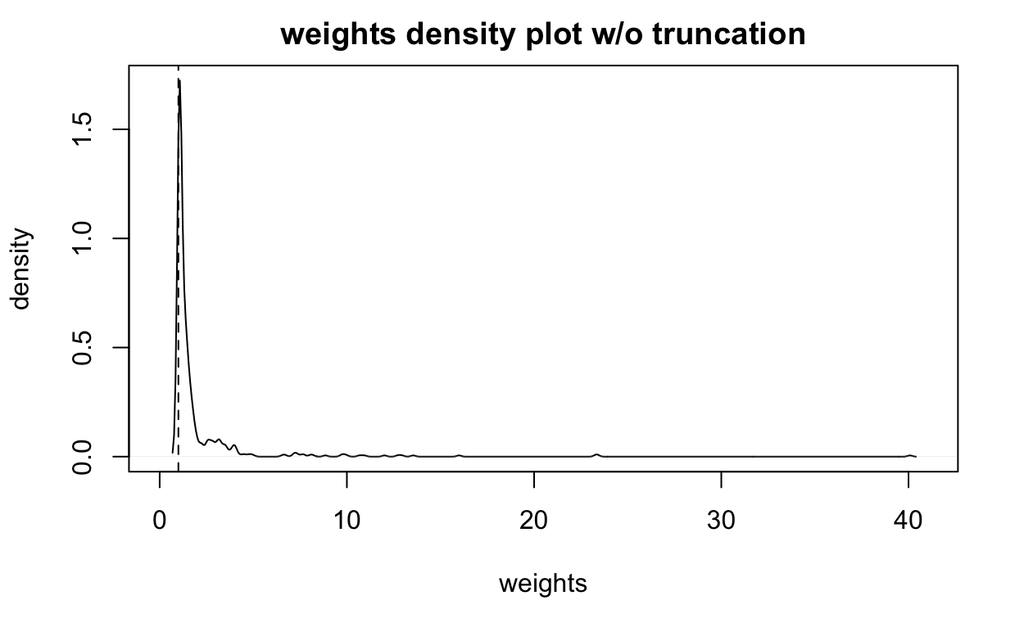

```r
# 1. specify the propensity score model
weightmodel <- ipwpoint(exposure = treat, family = "binomial", link = "logit",
                        denominator = ~ age+educ+black+hispan+married+nodegree+re74+re75,
                        data = lalonde)

# 2. plot of the weights (density plot)
ipwplot(weights = weightmodel$ipw.weights, logscale = FALSE, main = "weights density plot w/o truncation",
        xlim = c(0,41), xlab = "weights") # x-range (0,41) b/c from Q1 we know that min. weight ca. 1 and max weight ca. 40
```

```r
# 3. add weights to lalonde dataframe
lalonde$wt <- weightmodel$ipw.weights

# 4. # fit a marginal structural model (MSM) to compute risk difference
msm <- svyglm(formula = re78 ~ treat,
               design = svydesign(~1, weights = ~wt, data = lalonde))

# 5. get coefficients
coef(msm)
```

```
(Intercept)       treat
  6422.8390    224.6763
```

```r
# 6. compute confidence intervals
cat("The 95% CI for each coefficient:")
```

```
The 95% CI for each coefficient:
```

```r
confint(msm)
```

```
                2.5 %   97.5 %
(Intercept)  5706.948 7138.730
treat       -1559.321 2008.673
```

#### Q3 answer: The estimand of the coefficient of treatment in the MSM (i.e. average causal effect (ACE)) is: 224.68. The 95% confidence interval (CI) is: (-1559.32, 2008.67).

### Q4 Tasks:

#### Now truncate the weights at the 1st and 99th percentiles. This can be done with the trunc=0.01 option in svyglm.

```r
# 1. specify the propensity score model
weightmodel_trunc <- ipwpoint(exposure = treat, family = "binomial", link = "logit",
                        denominator = ~ age+educ+black+hispan+married+nodegree+re74+re75,
                        data = lalonde,
                        trunc = 0.01) #truncates top and bottom 1% of weights

# add truncated weights to lalonde dataframe
lalonde$wt_trunc <- weightmodel_trunc$weights.trunc

# 2. display summary of truncated weights
summary(lalonde$wt_trunc, digits=3)
```

```
   Min. 1st Qu.  Median    Mean 3rd Qu.    Max.
   1.01    1.05    1.17    1.82    1.62   12.60
```

##### We observe that the truncated weights only range from ca. 1-13 and not anymore more 1-40 as before. Let’s have a look at the weights density plot.

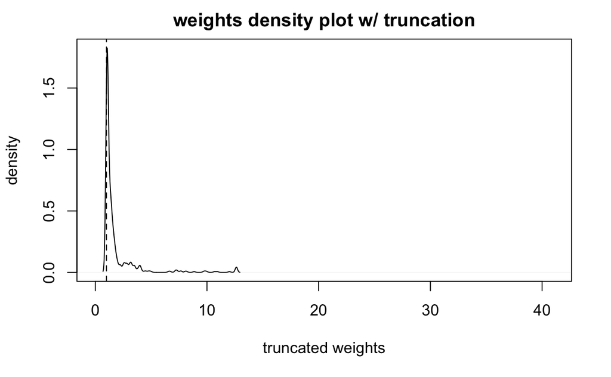

```r
# 3. plot of the weights (density plot)
ipwplot(weights = weightmodel_trunc$weights.trunc, logscale = FALSE, main = "weights density plot w/ truncation", xlim = c(0,41), xlab = "truncated weights") # x-range (0,41) b/c from Q4 (above) we know that min. weight ca. 1 and max weight ca. 40
```

```r
# now we repeat process from Q3:
# 4. # fit a marginal structural model (MSM) to compute risk difference
msm_trunc <- svyglm(formula = re78 ~ treat,
               design = svydesign(~1, weights = ~wt_trunc, data = lalonde))

# 5. get coefficients
coef(msm_trunc)
```

```
(Intercept)       treat
  6422.9362    486.9336
```

```r
# 6. compute confidence intervals
cat("The 95% CI for each coefficient:")
```

```
The 95% CI for each coefficient:
```

```r
confint(msm_trunc)
```

```
                2.5 %   97.5 %
(Intercept)  5707.033 7138.840
treat       -1090.639 2064.506
```

#### Q4 answer: The estimand of the coefficient of treatment in the MSM (i.e. average causal effect (ACE)) with truncated weights a 1st and 99th percentiles is: 486.93. The 95% confidence interval (CI) is: (-1090.64, 2064.51).